# Homework #2

Jacob Shoemaker; jshoemaker2249

This homework is about syntax and basic plotting functions in R, and is **due on Feb 5** before class.

**Submission instructions**: Create a folder named `ds202_hw2`, and name the RMarkDown file including your solutions `hw2.Rmd` under this folder. For submission, create a GitHub repository named `ds202_hw2` under your account, and push both `hw2.Rmd` and the knitted `hw2.html` to GitHub before the deadline. I will assume you use the same GitHub username as for your HW1 submission. The latest version of your homework appearing on GitHub before the deadline is graded. *It is crucial to follow the exact folder structure and file names*, so that your homework can be reproduced and graded by an automated script. Some questions will require the following answer format.

## Example question and answer

0. What is the smallest positive odd integer? Storage it in a variable named `a0` and print it.

```r
a0 <- 1
a0
```

```
## [1] 1
```

## R commands

1. Today’s temperature has a high of 15 and a low of -10 degree fahrenheit. Find the corresponding degress in celsius and storage it in a (single) vector named `cel`. Print the variable.

```r
cel <- c(-9.44, -23.33)
cel
```

```
## [1]  -9.44 -23.33
```

2. Create a vector of length 200. The odd entries should be 1 and even entries should be 0. Storage the created in a variable named `vec200` and print.

```r
vec200 <- rep(c(0,1), length.out = 200)
vec200
```

```
##   [1] 0 1 0 1 0 1 0 1 0 1 0 1 0 1 0 1 0 1 0 1 0 1 0 1 0 1 0 1 0 1 0 1 0 1 0
##  [36] 1 0 1 0 1 0 1 0 1 0 1 0 1 0 1 0 1 0 1 0 1 0 1 0 1 0 1 0 1 0 1 0 1 0 1
##  [71] 0 1 0 1 0 1 0 1 0 1 0 1 0 1 0 1 0 1 0 1 0 1 0 1 0 1 0 1 0 1 0 1 0 1 0
## [106] 1 0 1 0 1 0 1 0 1 0 1 0 1 0 1 0 1 0 1 0 1 0 1 0 1 0 1 0 1 0 1 0 1 0 1
## [141] 0 1 0 1 0 1 0 1 0 1 0 1 0 1 0 1 0 1 0 1 0 1 0 1 0 1 0 1 0 1 0 1 0 1 0
## [176] 1 0 1 0 1 0 1 0 1 0 1 0 1 0 1 0 1 0 1 0 1 0 1 0 1
```

3. How many perfect squares are there between 1 and 1001? Storage the answer in a variable named `numPerfect` and print. You may want to look at `?round`.

```r
numPerfect <- (1 + floor(sqrt(1001)) - ceiling(sqrt(1)))
numPerfect
```

```
## [1] 31
```

## Cars and mileage

```r
library(ggplot2)
```

1. What are the 3 most fuel-efficient models in terms of highway mileage? Storage the data frame (with 3 rows) containing all information of these three cars in a variable named `top3` and print.

```r
top3 <- head(mpg[order(-mpg$hwy),],3)
top3
```

```
## # A tibble: 3 x 11
##   manufacturer model  displ  year   cyl trans drv     cty   hwy fl    class
##   <chr>        <chr>  <dbl> <int> <int> <chr> <chr> <int> <int> <chr> <chr>
## 1 volkswagen   jetta    1.9  1999     4 manu~ f        33    44 d     comp~
## 2 volkswagen   new b~   1.9  1999     4 manu~ f        35    44 d     subc~
## 3 volkswagen   new b~   1.9  1999     4 auto~ f        29    41 d     subc~
```

2. How many different compact models are included in this dataset? Storage the answer in a variable named `numCompact` and print.

```r
numCompact <- nrow(mpg[mpg$class == 'compact', ])
numCompact
```

```
## [1] 47
```

3. Create a scatterplot of `hwy` and `cty` and describe the relationship. Why are there so few points visible?

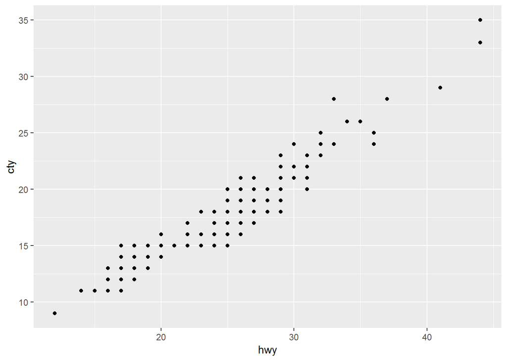

```r
ggplot(mpg, aes(x=hwy, y=cty)) + geom_point()
```

**Why are there so few points visible?**  
Not all of the points are visible because there are some duplicate rows in which there are the same fuel efficiency stats.

```r
#Breaking up the dataframe in two based on year
dat1999 <- mpg[mpg$year == '1999', ]
dat2008 <- mpg[mpg$year == '2008', ]

#Summary Statistics of both years, city
summary(dat1999$cty)
```

```
##    Min. 1st Qu.  Median    Mean 3rd Qu.    Max.
##   11.00   14.00   17.00   17.02   19.00   35.00
```

```r
summary(dat2008$cty)
```

```
##    Min. 1st Qu.  Median    Mean 3rd Qu.    Max.
##     9.0    13.0    17.0    16.7    20.0    28.0
```

```r
#Summary Statistics of both years, highway
summary(dat1999$hwy)
```

```
##    Min. 1st Qu.  Median    Mean 3rd Qu.    Max.
##   15.00   17.00   25.00   23.43   26.00   44.00
```

```r
summary(dat2008$hwy)
```

```
##    Min. 1st Qu.  Median    Mean 3rd Qu.    Max.
##   12.00   18.00   24.00   23.45   28.00   37.00
```

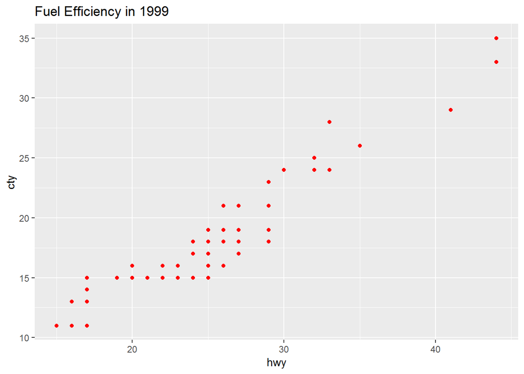

```r
#Graph the fuel efficiency of 1999
ggplot(dat1999, aes(x=hwy, y=cty)) + geom_point(colour="red") + ggtitle("Fuel Efficiency in 1999")
```

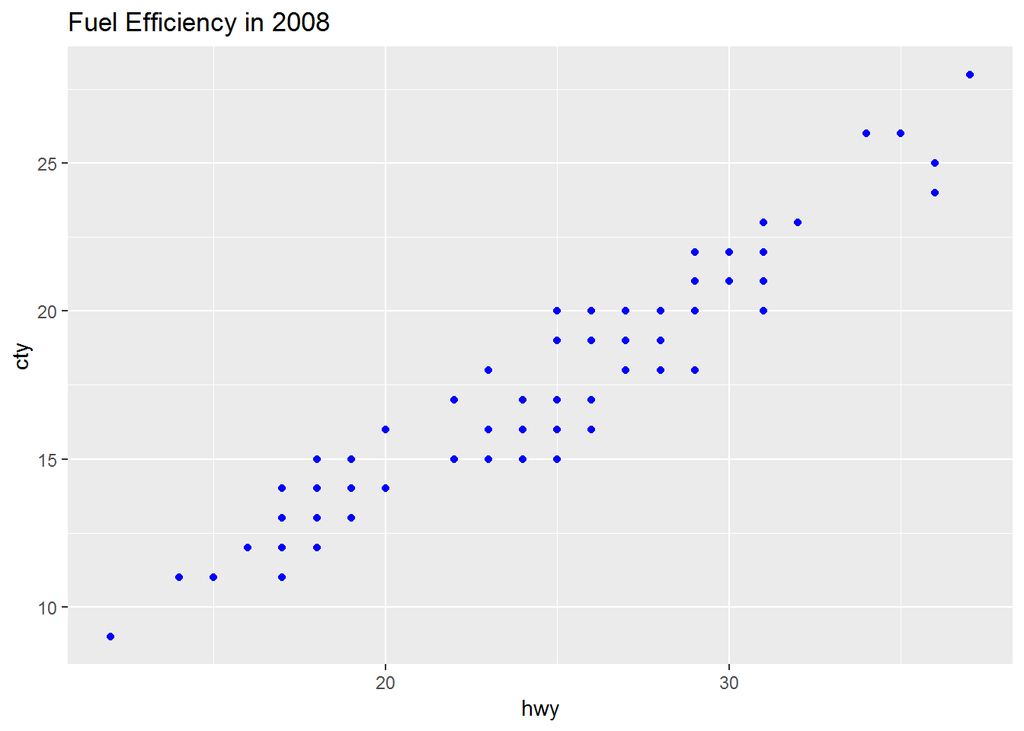

```r
#Graph from 2008
ggplot(dat2008, aes(x=hwy, y=cty)) + geom_point(colour = "blue") + ggtitle("Fuel Efficiency in 2008")
```

Note: your submission is supposed to be fully reproducible, i.e. the TA and I will ‘knit’ your submission. Make sure that you don’t use any file structure that depends on your computing environment.